# Bay Wheels Analysis

## Project Objectives

For my final Udacity project on Data Visualization, I will pick a dataset to wrangle and conduct **exploratory** analyses. After reviewing the data, I will create a presentation using **explanatory** visualizations.

## Data overview

I will investigate the **Bay Wheels system data** publicly available on [Lyft's website](https://www.lyft.com/bikes/bay-wheels/system-data). Lyft is America's second biggest ride-sharing company, and since last year, the company started [offering bike-share](https://blog.lyft.com/posts/lyft-becomes-americas-largest-bikeshare-service) and then scooter-share. Their bike sharing network was called Ford GoBike in the San Francisco Bay Area (originally by the service company Motivate which got acquired by Lyft) until Lyft [rebranded them as Lyft](https://techcrunch.com/2019/06/11/lyft-deploys-its-pink-wheeled-bikes-and-rebrands-ford-gobike-as-bay-wheels/).

- Data Gathering and Wrangling
- Exploratory Analysis

```python
# import all packages and set plots to be embedded inline
import numpy as np
import pandas as pd
import matplotlib.pyplot as plt
import seaborn as sns

%matplotlib inline

import requests
import zipfile
from io import BytesIO
from os import makedirs, listdir

import datetime
import math
```

## Data Gathering and Wrangling

#### Download the Dataset

Programatically download the zip files starting from January 2018 from the [website](https://s3.amazonaws.com/baywheels-data/index.html). Then extract all zip files and read their csv file.

```python
# Create folder to store data
folder_name = "trip_data"
if not os.path.exists(folder_name):
    makedirs(folder_name)

# Download and extract files
i = 1
year_month = "201801"

while year_month != "201909":

    # Get response from url
    if year_month < "201905":
        """FordGoBike in URL before 201905"""
        filename = year_month + "-fordgobike-tripdata.csv.zip"
    else:
        filename = year_month + "-baywheels-tripdata.csv.zip"

    url = "https://s3.amazonaws.com/baywheels-data/" + filename
    response = requests.get(url)

    # Download and read zip file in memory using ZipFile(BytesIO(...))
    unzipped_file = zipfile.ZipFile(BytesIO(response.content))

    # Place extracted file into folder
    unzipped_file.extractall(folder_name)

    year_month = str(2018 + i//12) + ("0" + str(i%12+1))[-2:]
    i += 1
```

```python
l = []

for file in listdir(folder_name):
    try:
        l.append(pd.read_csv(folder_name + '/' + file, engine = "python"))
    except:
        "Cannot read file: {}.".format(file)
```

#### Transform the Dataset

Merge these dataframes into one large dataframe. Investigate and clean the data.

```python
print("There are {} dataframes with the following dimensions:".format(len(l)))
for i in l:
    print(i.shape)
```

```
There are 20 dataframes with the following dimensions:
(106718, 16)
(134135, 16)
(239111, 16)
(186217, 16)
(195968, 16)
(199872, 17)
(256299, 16)
(191772, 17)
(179125, 16)
(210563, 16)
(131363, 16)
(94802, 16)
(182163, 16)
(192082, 16)
(199222, 16)
(192162, 16)
(201458, 16)
(111382, 16)
(131169, 16)
(183412, 16)
```

There are 16 columns in all the datasets except for 2, which include 17 columns.

```python
print(l[5].columns)
print(l[7].columns)
```

```
Index(['duration_sec', 'start_time', 'end_time', 'start_station_id',
       'start_station_name', 'start_station_latitude',
       'start_station_longitude', 'end_station_id', 'end_station_name',
       'end_station_latitude', 'end_station_longitude', 'bike_id', 'user_type',
       'member_birth_year', 'member_gender', 'bike_share_for_all_trip',
       'Unnamed: 16'],
      dtype='object')
Index(['duration_sec', 'start_time', 'end_time', 'start_station_id',
       'start_station_name', 'start_station_latitude',
       'start_station_longitude', 'end_station_id', 'end_station_name',
       'end_station_latitude', 'end_station_longitude', 'bike_id', 'user_type',
       'member_birth_year', 'member_gender', 'bike_share_for_all_trip',
       'rental_access_method'],
      dtype='object')
```

The files with 17 columns have the extra column at the end. One includes `rental_access_method` which is how the customer paid, while the other includes `Unnamed: 16`. For consistency, we will ignore these columns.

```python
# Drop extra columns
l[7].drop(columns = "rental_access_method", inplace=True)
l[5].drop(columns = "Unnamed: 16", inplace=True)
```

```python
# Check columns have been successfully dropped
print("There are {} dataframes with the following dimensions:".format(len(l)))
for i in l:
    print(i.shape)
```

```
There are 20 dataframes with the following dimensions:
(106718, 16)
(134135, 16)
(239111, 16)
(186217, 16)
(195968, 16)
(199872, 16)
(256299, 16)
(191772, 16)
(179125, 16)
(210563, 16)
(131363, 16)
(94802, 16)
(182163, 16)
(192082, 16)
(199222, 16)
(192162, 16)
(201458, 16)
(111382, 16)
(131169, 16)
(183412, 16)
```

```python
# Merge all dataframes together
df = pd.concat(l)
```

```python
# Save file
df.to_csv("bikeshare_data.csv", index=False)
```

#### Clean the Dataset

Mainly convert fields to their appropriate types and know which values could be missing.

```python
df = pd.read_csv("bikeshare_data.csv")
```

```python
df.info(null_counts=True)
```

```
<class 'pandas.core.frame.DataFrame'>
RangeIndex: 3518995 entries, 0 to 3518994
Data columns (total 16 columns):
duration_sec               3518995 non-null int64
start_time                 3518995 non-null object
end_time                   3518995 non-null object
start_station_id           3485280 non-null float64
start_station_name         3485284 non-null object
start_station_latitude     3518995 non-null float64
start_station_longitude    3518995 non-null float64
end_station_id             3484552 non-null float64
end_station_name           3484555 non-null object
end_station_latitude       3518995 non-null float64
end_station_longitude      3518995 non-null float64
bike_id                    3518995 non-null int64
user_type                  3518995 non-null object
member_birth_year          3266522 non-null float64
member_gender              3269477 non-null object
bike_share_for_all_trip    3485478 non-null object
dtypes: float64(7), int64(2), object(7)
memory usage: 429.6+ MB
```

Converting all columns to their correct types.

```python
# Cast start_time and end_time as datetime
df.start_time = pd.to_datetime(df.start_time)
df.end_time = pd.to_datetime(df.end_time)
df.dtypes
```

```
duration_sec                        int64
start_time                 datetime64[ns]
end_time                   datetime64[ns]
start_station_id                  float64
start_station_name                 object
start_station_latitude            float64
start_station_longitude           float64
end_station_id                    float64
end_station_name                   object
end_station_latitude              float64
end_station_longitude             float64
bike_id                             int64
user_type                          object
member_birth_year                 float64
member_gender                      object
bike_share_for_all_trip            object
dtype: object
```

```python
# Cast station IDs as integer
df.start_station_id = df.start_station_id.astype(pd.Int64Dtype())
df.end_station_id = df.end_station_id.astype(pd.Int64Dtype())
df.dtypes
```

```
duration_sec                        int64
start_time                 datetime64[ns]
end_time                   datetime64[ns]
start_station_id                    Int64
start_station_name                 object
start_station_latitude            float64
start_station_longitude           float64
end_station_id                      Int64
end_station_name                   object
end_station_latitude              float64
end_station_longitude             float64
bike_id                             int64
user_type                          object
member_birth_year                 float64
member_gender                      object
bike_share_for_all_trip            object
dtype: object
```

```python
# Cast member_birth_year as integer
df.member_birth_year = df.member_birth_year.astype(pd.Int64Dtype())
```

```python
# Check categories in member_gender
df.member_gender.unique()
```

```
array(['Male', 'Female', nan, 'Other', '?', 'M', 'F', 'O'], dtype=object)
```

- `member_gender` should be "Male", "Female", "Other", or "nan".

Correct the `member_gender` categories.

```python
# Correct member_gender values
genders = {"M": "Male", "F": "Female", "O": "Other", "?": np.nan, "Male": "Male", "Female" : "Female", "Other" : "Other"}

df.member_gender = df.member_gender.map(genders)
df.member_gender.unique()
```

```
array(['Male', 'Female', nan, 'Other'], dtype=object)
```

```python
# Check if bike_share_for_all_trip is valid
df.bike_share_for_all_trip.unique()
```

```
array(['No', 'Yes', nan], dtype=object)
```

```python
# Correct bike_share_for_all_trip type to boolean
bikes = {"No" : False, "Yes" : True}

df.bike_share_for_all_trip = df.bike_share_for_all_trip.map(bikes)
df.bike_share_for_all_trip.unique()
```

```
array([False, True, nan], dtype=object)
```

```python
# Check that all stations are in the San Francisco region
df.start_station_name.unique()
```

[output not shown]

[output cut: 169 more lines]

```
       'Balboa Park BART Station', 'Gennessee St at Monterey Blvd',
       '4th St at San Carlos St', 'Bird Ave at Willow St',
       'Stockton Ave at Lenzen Ave', 'Auzerais Ave at Lincoln Ave',
       '23rd St at Taylor St', 'Emeryville Depot', 'MTL-ECO5-01',
       'San Jose Depot', 'W Julian St at N Morrison St',
       'Mint St at Mission St', 'Utah St at 24th St',
       'Natoma St at New Montgomery St', 'Folsom St at 2nd St',
       '1st St at San Carlos St', 'Emory St at The Alameda',
       '7th St at Empire St', 'Jackson St at N 1st St',
       'Outside Lands (Temporary Station)',
       'Woolsey St at Sacramento St1', 'Laguna St at McAllister St',
       '2nd St at S Park St',
       'Miles Ave at Cavour St (Temporary Location)',
       'E 12th St at 6th Ave', 'E 12th St at 4th Ave',
       'Outside Lands 2018 (Temporary Station)'], dtype=object)
```

```python
# Filter dataset to San Francisco only (remove East Bay and South Bay)
max_longitude = -122.3571
min_longitude = -122.5147
max_latitude = 37.8108
min_latitude = 37.7084

end_station_latitude = (df['end_station_latitude']>=min_latitude) & (df['end_station_latitude']<=max_latitude)
start_station_latitude = (df['start_station_latitude']>=min_latitude) & (df['start_station_latitude']<=max_latitude)
end_station_longitude =(df['end_station_longitude']>=min_longitude) & (df['end_station_longitude']<=max_longitude)
start_station_longitude = (df['start_station_longitude']>=min_longitude) & (df['start_station_longitude']<=max_longitude)

df = df[end_station_latitude & start_station_latitude & end_station_longitude & start_station_longitude]
```

```python
df.to_csv("bikeshare_data_clean.csv", index=False)
```

```python
df.shape
```

```
(2566518, 16)
```

## Exploratory Analysis

### What is/are the main feature(s) of interest in your dataset?

> - **User Information:** How many trips are taken by subscribers? What is the age distribution? What is the gender distribution?
> - **Trip Details:** How long does an average trip take? How far is an average trip?
> - **Station Details:** Which stations are most frequently visited?
> - **Busy Hours:** What time of day, day of week, and month of year are most trips taken?

### What features in the dataset do you think will help support your investigation into your feature(s) of interest?

> - Calculate `member_age` from `member_birth_year`.
> - Calculate `hour`, `day_of_week`, and `month` from `start_time`.

#### User Information

```python
df = pd.read_csv("bikeshare_data_clean.csv")

# Cast start_time and end_time as datetime (if loaded from csv)
df.start_time = pd.to_datetime(df.start_time)
df.end_time = pd.to_datetime(df.end_time)
```

```
Subscriber 2150716
Customer 415802
```

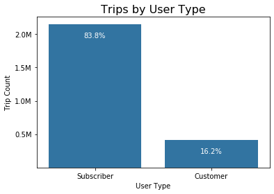

```python
# How many trips are taken by subscribers?

sns.countplot(data = df, x = "user_type", color = sns.color_palette()[0]);
plt.title("Trips by User Type", size=16);
plt.xlabel("User Type");
plt.ylabel("Trip Count");
plt.yticks([500000, 1000000, 1500000, 2000000],["0.5M","1.0M","1.5M","2.0M"]);

# Create annotations
locs, labels = plt.xticks();# get the current tick locations and labels
user_counts = df['user_type'].value_counts()
# loop through each pair of locations and labels
for loc, label in zip(locs, labels):
    # get the text property for the label to get the correct count
    count = user_counts[label.get_text()]
    print(label.get_text(), count);
    pct_string = '{:0.1f}%'.format(100*count/df.shape[0])
    # print the annotation just below the top of the bar
    plt.text(loc, count-200000, pct_string, ha = 'center', color = 'w')
```

Since January 2018, there have been 2,150,716 trips taken by Subscribers and 415,802 trips taken by Customers in San Francisco. Subscribers represent 84% of the user base.

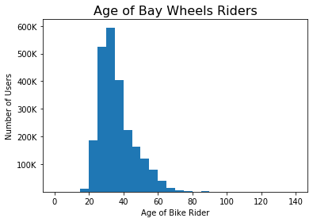

```python
# What is the age distribution of rides?

# Create age variable
df['member_age'] = 2019 - df.member_birth_year

# Create histogram
df.member_age.hist(bins = np.arange(0,np.max(df.member_age),5), grid = False);
plt.title("Age of Bay Wheels Riders", size=16);
plt.xlabel("Age of Bike Rider");
plt.ylabel("Number of Users");
plt.yticks([1e5,2e5,3e5,4e5,5e5,6e5],["100K","200K","300K","400K","500K","600K"]);
```

The age distribution of bike riders is skewed right, but there are strange outliers, including a user riding a bike at 140 years old...

I should remove the outliers and plot the distribution again.

```python
# There are too many outliers (riders at 140 years old is not practical)
df.member_age.describe(percentiles=[0,.25,.5,.75,.8,.9,.95])
```

```
count    2.368863e+06
mean     3.560064e+01
std      1.011896e+01
min      1.800000e+01
0%       1.800000e+01
25%      2.800000e+01
50%      3.300000e+01
75%      4.100000e+01
80%      4.300000e+01
90%      5.100000e+01
95%      5.600000e+01
max      1.410000e+02
Name: member_age, dtype: float64
```

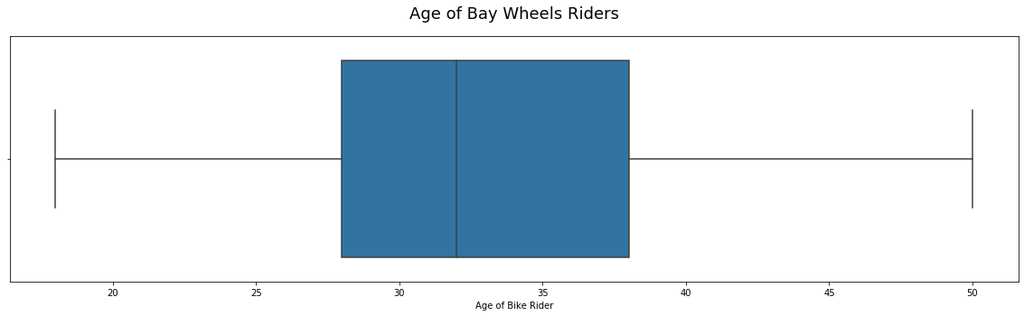

```python
# 90% of riders are 50 years old or under
plt.figure(figsize=[20,5]);
p = df[df.member_age <= 50]
sns.boxplot(data = p, x = "member_age");
plt.title("Age of Bay Wheels Riders", fontsize=18, y = 1.05);
plt.xlabel("Age of Bike Rider");
```

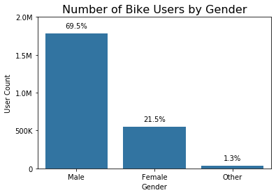

```python
# What is the gender distribution
sns.countplot(data = df, x = "member_gender", color = sns.color_palette()[0])
plt.title("Number of Bike Users by Gender", size=16);
plt.xlabel("Gender");
plt.ylabel("User Count");
plt.ylim(0,2000000)
plt.yticks([0,5e5,1e6, 15e5, 2e6],["0","500K","1.0M","1.5M","2.0M"])

# Create annotations
locs, labels = plt.xticks();# get the current tick locations and labels
user_counts = df['member_gender'].value_counts()
# loop through each pair of locations and labels
for loc, label in zip(locs, labels):
    # get the text property for the label to get the correct count
    count = user_counts[label.get_text()]
    pct_string = '{:0.1f}%'.format(100*count/df.shape[0])
    # print the annotation just below the top of the bar
    plt.text(loc, count+70000, pct_string, ha = 'center', color = 'k')
```

The majority of bike riders are male, then female, then those who identify as Other or Unknown.

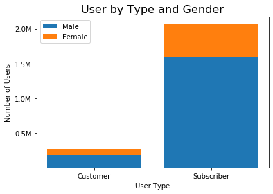

```python
users = ["Customer","Subscriber"]
genders = ["Male", "Female","Other"]

b = np.zeros(2)

for i in range(len(users)):
    gender = genders[i]
    user_counts = df[df.member_gender == gender]["user_type"].value_counts()
    plt.bar(x = np.arange(2), height = user_counts[users], bottom = b);
    b += user_counts[users]

plt.xticks(np.arange(2), users);
plt.legend(genders);
plt.title("User by Type and Gender", size=16);
plt.xlabel("User Type");
plt.ylabel("Number of Users");
plt.yticks([5e5,1e6,15e5,2e6],["0.5M","1.0M","1.5M","2.0M"]);
```

While there are more subscribers than customers, both user types are still majority male.

#### Trip Details

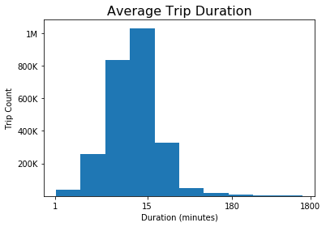

```python
# How long does an average trip take?
# sns.boxplot(data = df, x = "duration_sec");
# plt.title("Age of Bay Wheels Riders", fontsize=18, y = 1.05);
# plt.xlabel("Age of Bike Rider");

p = np.log10(df.duration_sec)
p.hist(grid = False);
plt.title("Average Trip Duration", size=16);
plt.xlabel("Duration (minutes)");
plt.ylabel("Trip Count");
plt.xticks([np.log10(1*60), np.log10(15*60), np.log10(180*60), np.log10(1800*60)],[1, 15, 180, 1800]);
plt.yticks([2e5,4e5,6e5,8e5,1e6],["200K","400K","600K","800K","1M"]);
```

The most trips take around 15 minutes. The average is slightly below.

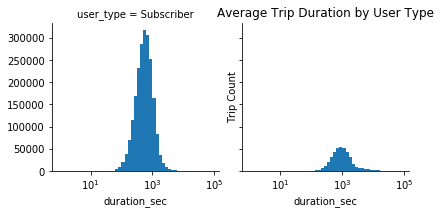

```python
# How does trip duration vary by customer type?

p = sns.FacetGrid(data = df, col = "user_type")
p.map(plt.hist, "duration_sec", bins = 10**np.arange(0, np.log10(df.duration_sec.max()),.1))
plt.title("Average Trip Duration by User Type");
plt.ylabel("Trip Count");
plt.xscale("log");
```

Overall, it looks like the duration between user types are similar. Subscribers have more volume of rides.

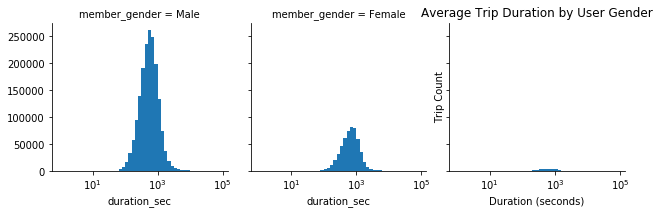

```python
# How does trip duration vary by gender?

p = sns.FacetGrid(data = df, col = "member_gender")
p.map(plt.hist, "duration_sec", bins = 10**np.arange(0, np.log10(df.duration_sec.max()),.1))
plt.title("Average Trip Duration by User Gender");
plt.xlabel("Duration (seconds)");
plt.ylabel("Trip Count");
plt.xscale("log");
```

```python
# What is the average distance? This is assuming a straight path

def distance(start_lat, start_long, end_lat, end_long):
        """Take Pythagorean Theorem"""
        lat_distance = abs(start_lat - end_lat)
        long_distance = abs(start_long - end_long)
        return math.sqrt(lat_distance**2 + long_distance**2) * 69.2

df["distance"] = df.apply(lambda x: distance(x.start_station_latitude , x.start_station_longitude,
                                            x.end_station_latitude, x.end_station_longitude), axis = 1)
```

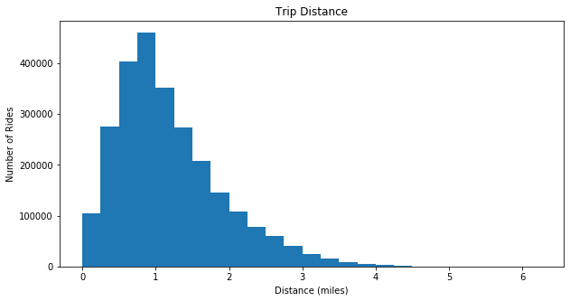

```python
plt.figure(figsize=[10,5])
df.distance.hist(grid = False, bins = np.arange(0,6.5,.25));
plt.title("Trip Distance");
plt.xlabel("Distance (miles)");
plt.ylabel("Number of Rides");
```

Most bike rides approximate 1 mile, while the majority of trips don't stop at stations over 4 miles apart. This is likely a threshold for people to consider other modes of transportation, such as bus, metro, or rideshare.

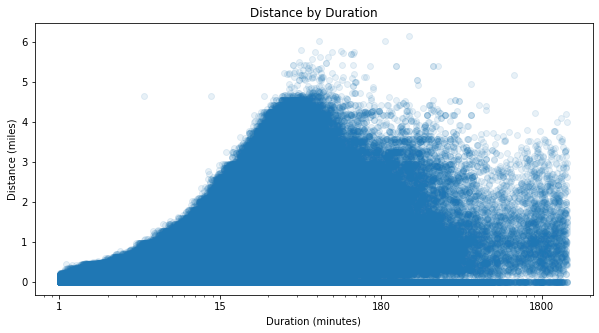

```python
p = df[~(df.duration_sec.isnull()) & ~(df.distance.isnull())]
p["duration_minutes"] = p.apply(lambda x: x.duration_sec/60, axis=1)
plt.figure(figsize=[10,5])
plt.scatter(data=p, x="duration_minutes",y="distance", alpha=.1);
plt.xscale("log");
plt.xlabel("Duration (minutes)");
plt.ylabel("Distance (miles)");
plt.title("Distance by Duration");
plt.xticks([1, 10, 100, 1000],[1, 15, 180, 1800]);
```

Like the previous analysis, most rides occur under 4 miles. Rides take longer time the farther the user travels, until after a certain duration. It seems like if the user rides for a long period of time (beyond the typical 15-30 minutes), they are probably resting with the bike reserved for them. It is possible they are tourists. There also seem to be some rides with no travel distance but long duration; this might mean that the rider made a round trip, parking at the same station.

#### Station Details

In order to plot which stations riders tend to travel to and from, I need to filter rides to only include San Francisco stations.

```python
max_longitude = -122.3571
min_longitude = -122.5147
max_latitude = 37.8108
min_latitude = 37.7084

m = df[~start_station_latitude.isnull() & ~start_station_longitude.isnull() & ~end_station_latitude.isnull() & ~end_station_longitude.isnull()];
p = m.sample(5000)
```

```python
start_stations = m[["start_station_name", "start_station_latitude", "start_station_longitude"]]
end_stations = m[["end_station_name", "end_station_latitude", "end_station_longitude"]]

start_stations.rename(columns={"start_station_name":"station_name", "start_station_latitude":"station_latitude", "start_station_longitude":"station_longitude"}, inplace=True)
end_stations.rename(columns={"end_station_name":"station_name", "end_station_latitude":"station_latitude", "end_station_longitude":"station_longitude"}, inplace=True)
stations = pd.concat([start_stations, end_stations])

stations = stations.drop_duplicates()
```

```python
x = stations.iloc[0]
x.station_longitude
```

```
-122.40087568759917
```

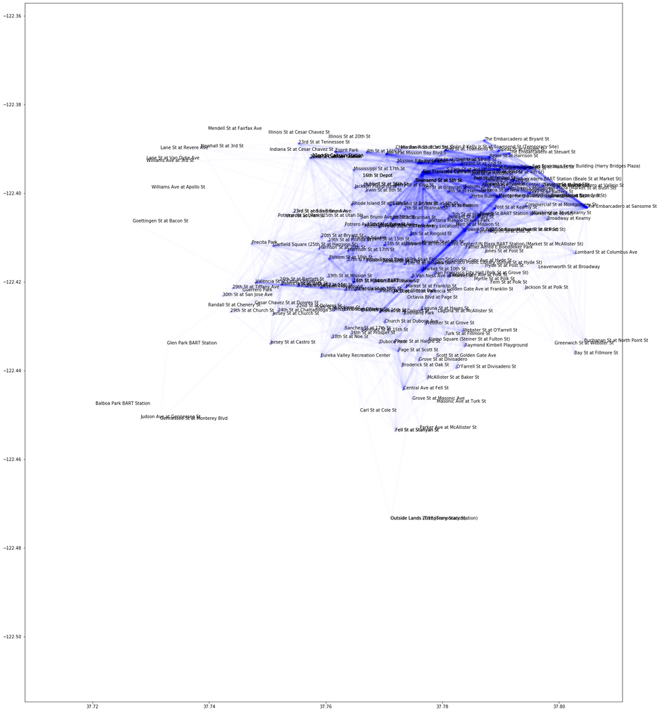

```python
plt.figure(figsize=[25,30])

for i in range(len(p)):
    x = [p.iloc[i].start_station_latitude, p.iloc[i].end_station_latitude]
    y = [p.iloc[i].start_station_longitude, p.iloc[i].end_station_longitude]
    plt.plot(x, y, 'b-', alpha = .01, lw=5, solid_capstyle='round');

for i in range(len(stations)):
    x = stations.iloc[i]
    plt.annotate(x.station_name, (x.station_latitude, x.station_longitude));

plt.ylim(min_longitude, max_longitude);
plt.xlim(min_latitude, max_latitude);
plt.show();
```

Most trips occur in Financial District of San Francisco, as the paths are more travelled (graph looks denser). There's a long dense line through the city, representing Market Street. The edge represents the bikers riding along the water in Embarcadero.

#### Busy Hours

Busy Hours: What time of day, day of week, and month of year are most trips taken?

```python
df["start_hour"] = df.apply(lambda x: x.start_time.hour, axis = 1)
df["start_month"] = df.apply(lambda x: x.start_time.month, axis = 1)
df["start_weekday"] = df.apply(lambda x: x.start_time.isoweekday(), axis = 1)
```

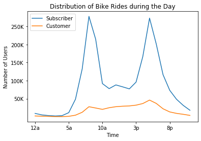

```python
# What time of day are trips taken?
p = df[df.user_type=="Subscriber"].groupby("start_hour").count().reset_index()
plt.plot("start_hour", "bike_id", data=p);
p = df[df.user_type=="Customer"].groupby("start_hour").count().reset_index()
plt.plot("start_hour", "bike_id", data=p);
plt.legend(["Subscriber","Customer"]);
plt.title("Distribution of Bike Rides during the Day", size = 16);
plt.yticks([50000,100000,150000,200000,250000],["50K","100K","150K","200K","250K"]);
plt.ylabel("Number of Users");
plt.xticks([0,5,10,15,20],["12a","5a","10a","3p","8p"]);
plt.xlabel("Time");
```

The majority of trips occur during morning and afternoon rush hour, indicating that many riders (especially Subscribers) are commuters.

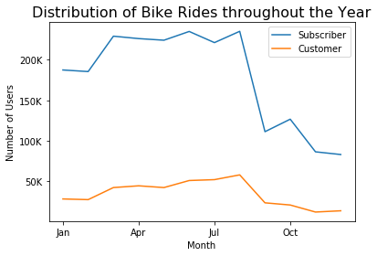

```python
# What months are trips taken?
p = df[df.user_type=="Subscriber"].groupby("start_month").count().reset_index()
plt.plot("start_month", "bike_id", data=p);
p = df[df.user_type=="Customer"].groupby("start_month").count().reset_index()
plt.plot("start_month", "bike_id", data=p);
plt.legend(["Subscriber","Customer"]);
plt.title("Distribution of Bike Rides throughout the Year", size = 16);
plt.yticks([50000,100000,150000,200000],["50K","100K","150K","200K"]);
plt.ylabel("Number of Users");
plt.xticks([1, 4, 7, 10],["Jan","Apr","Jul","Oct"]);
plt.xlabel("Month");
```

The winter time is when bike rides are the least popular, due to cold and windy weather in the Bay Area. There are slightly more Customers during July and August, which probably belong to tourists visiting the city.

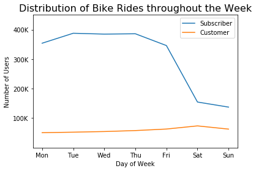

```python
# What day of week are trips taken?
p = df[df.user_type=="Subscriber"].groupby("start_weekday").count().reset_index()
plt.plot("start_weekday", "bike_id", data=p);
p = df[df.user_type=="Customer"].groupby("start_weekday").count().reset_index()
plt.plot("start_weekday", "bike_id", data=p);
plt.legend(["Subscriber","Customer"]);
plt.title("Distribution of Bike Rides throughout the Week", size = 16);
plt.yticks([1e5,2e5,3e5,4e5],["100K","200K","300K","400K"]);
plt.ylim(0,450000);
plt.ylabel("Number of Users");
plt.xticks([1, 2, 3, 4, 5, 6, 7],["Mon","Tue","Wed","Thu","Fri","Sat","Sun"]);
plt.xlabel("Day of Week");
```

The majority of rides occur during the weekdays from Subscribers who are likely commuters. There are more bike rides on Saturdays for Customers, which probably represent those visiting and exploring the city for the weekend.

## Conclusion

The average trip is 15 minutes long, with stations usually no more than 4 miles apart (most are 1 mile apart). There are some people who reserve their bikes for long periods of time, but start and end at the same station. The paths with the highest amount traffic include stations along Market Street and Financial District, where most people go to work. Some other popular paths and stations are along the water on Embarcadero.